# Part II - Impact of the borrower income and prosper score on the loan rate and amount

## by Murielle Souvenir LOKONON

## Investigation Overview

> In this investigation, I wanted to look at the effects of borrower income range and prosper score on the loan rate and original amount.

## Dataset Overview

> Here i analyze the prosper loans dataset. It contain 113,937 loans with 81 variables on each loan, including loan amount, borrower rate (or interest rate), current loan status, borrower income, and more. After the wrangling and removal of unused columns we have 113 937 rows and 14 columns.

## The borrower prosper score impact on the borrower rate

When searching the relationship of the prosper score and the borrower rate, we found that the worse is the posper score (10 to 1), the higher is the borrower rate.

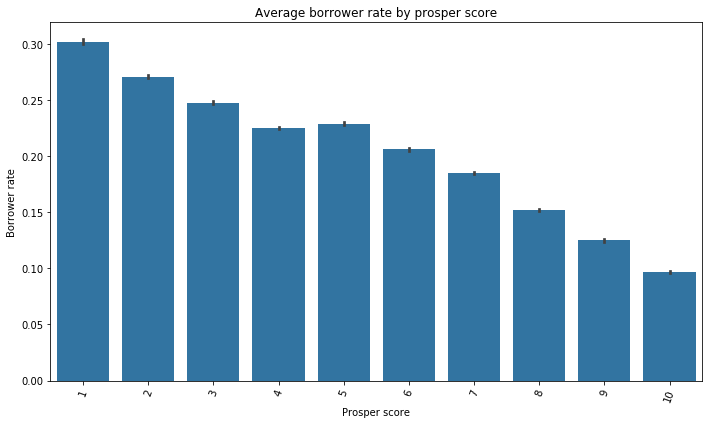

## The borrower prosper score impact on the loan original amount

The prosper score have also a relationship with the borrower loan amount. We found that the best is the prosper score (1 to 10), the higher is the loan original amount. So people with higner prosper score can borrow large amount of money.

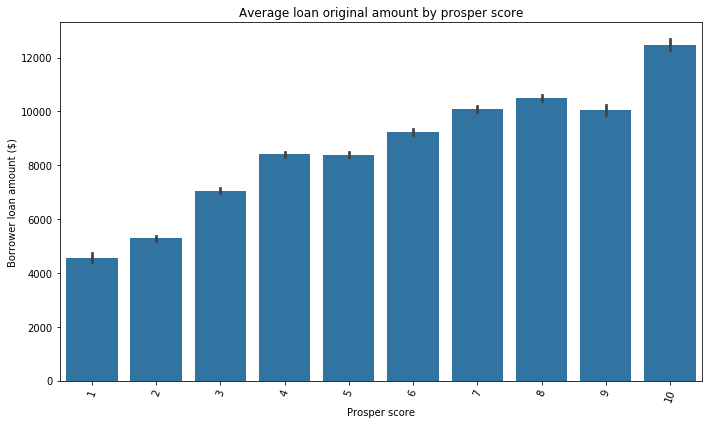

## The borrower income range impact on the loan original amount

For the income range and the loan original amount we found that the best is the income range, the higner is the loan original amount (except for $0 income range).

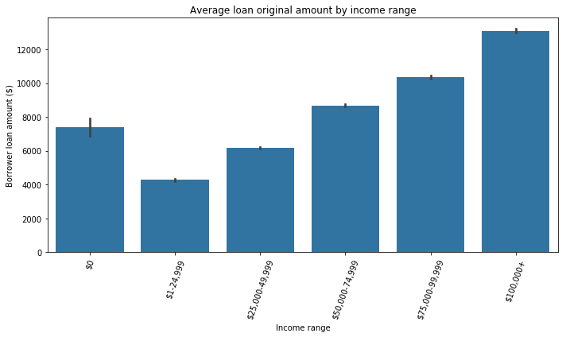

## The borrower income range impact on the borrower rate

For the income range and the loan original amount we found that the best is the income range, the lower is the loan borrower rate (except for $0 income range).

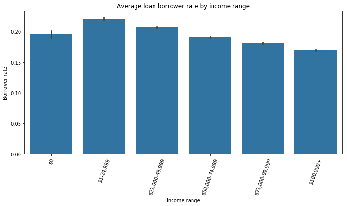